# Lead IQ Data Reprot

Jess Wild

September 12, 2020

## Package Instalation and Data Import

```r
#import the raw data
dat <- read.csv("C:/Users/jessi/Desktop/CU Denver Biostat PhD/6621/HW/HW 2/lead-iq-01.csv")
```

## Data Cleaning

An outlying datapoint (IQ = 999) was confirmed to be entered in error and should be IQ=99. The dataset was altered accordingly:

```r
#import the raw data
dat$IQ[which(dat$IQ==999)] <- 99
```

## Data Description

This data set includes information on the IQ of 124 people and a categorical variable describing how close they lived to a lead smelter. THe purpose of this dataset is to investigat the relationship between lead exposure and measured IQ level.

### Variable 1: Smelter

If a subject lives within one mile of a lead smelter, they are classified as ‘Near’, otherwise they are classified as ‘Far’. There were 57 observations classified as ‘Near’ and 67 observations classified as ‘Far’.

### Variable 2: IQ

Using the Wechsler Intelligence Scale for Children, each subject’s IQ score was recorded. The mean IQ score overall was 91.0806452. The mean IQ score for those calssified as near to a smelter was 89.1929825, and the mean for those classified as far from a smelter was 92.6865672.

### Data Tables

#### Data

The full data set is:

```r
knitr::kable(dat, caption = "TABLE 1")
```

TABLE 1

| Smelter | IQ |
| --- | --- |
| Far | 70 |
| Far | 85 |
| Far | 86 |
| Far | 76 |
| Far | 96 |
| Far | 94 |
| Far | 115 |
| Far | 97 |
| Far | 128 |
| Far | 99 |
| Far | 118 |
| Far | 141 |
| Far | 80 |
| Far | 101 |
| Far | 125 |
| Far | 96 |
| Far | 99 |
| Far | 96 |
| Far | 50 |
| Far | 99 |
| Far | 88 |
| Far | 120 |
| Far | 93 |
| Far | 78 |
| Far | 100 |
| Far | 105 |
| Far | 87 |
| Far | 94 |
| Far | 85 |
| Far | 94 |

[output cut: 94 more lines]

#### Descriptive Statistics

Some descriptive statistics for this data are:

```r
table1(~IQ+Smelter|Smelter, data = dat)
```

|  | Far (n=67) | Near (n=57) | Overall (n=124) |
| --- | --- | --- | --- |
| IQ |  |  |  |
| Mean (SD) | 92.7 (16.0) | 89.2 (12.2) | 91.1 (14.4) |
| Median [Min, Max] | 93.0 [46.0, 141] | 88.0 [56.0, 115] | 91.0 [46.0, 141] |
| Smelter |  |  |  |
| Far | 67 (100%) | 0 (0%) | 67 (54.0%) |
| Near | 0 (0%) | 57 (100%) | 57 (46.0%) |

## Data Visualization

To visualize the data, we can generate a boxplot stratified by proximity to a smelter:

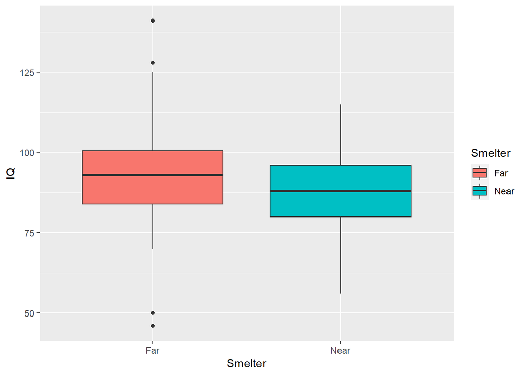

We can also generate a histogram of the data:

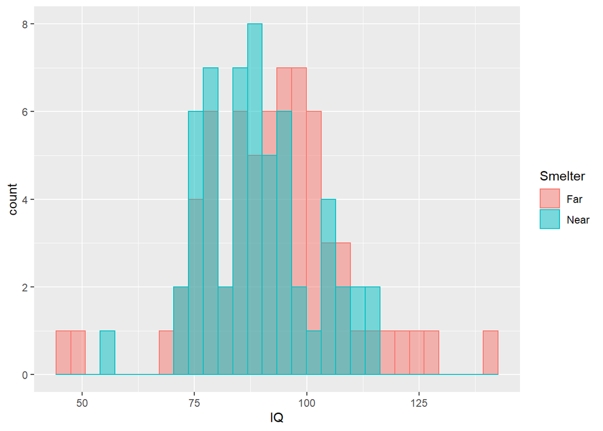